# Отчет по выполнению индивидуального проекта №2

Операционные системы

Кузьмин Егор Витальевич, НКАбд-03-23

Российский университет дружбы народов, Москва, Россия

16 марта 2024

## Цель работы

Продолжить работу со своим сайтом. Редактировать его в соответствии с требованиями. Добавить данные о себе. Добавить несколько постов

## Задание

0. Ознакомиться с технической стороной задания.
1. Разместить фотографию владельца сайта.
2. Разместить краткое описание владельца сайта (Biography).
3. Добавить информацию об интересах (Interests).
4. Добавить информацию от образовании (Education).
5. Сделать пост по прошедшей неделе.
6. Добавить пост на тему управление версиями. Git.

## Теоретическое введение

Hugo — генератор статических страниц для интернета.

Немного о статистических сайтах:

1. Статические сайты состоят из уже готовых HTML-страниц.
2. Эти страницы собираются заранее, а не готовятся для пользователя «на лету». Для этого используют генераторы статичных сайтов.
3. Так как это почти чистый HTML, то такие сайты быстрее загружаются и их проще переносить с сервера на сервер.
4. Минус: если нужно что-то обновить на странице, то сначала это правят в исходном файле, а потом запускают обновление в генераторе.
5. Ещё минус: такие страницы не подходят для интернет-магазинов или сайтов с личным кабинетом, потому что в статике нельзя сформировать страницу для каждого отдельного пользователя.

## Выполнение лабораторной работы

Добавляю свою фотографию в папку blog/content/authors/admin и удаляю фотографию шаблона

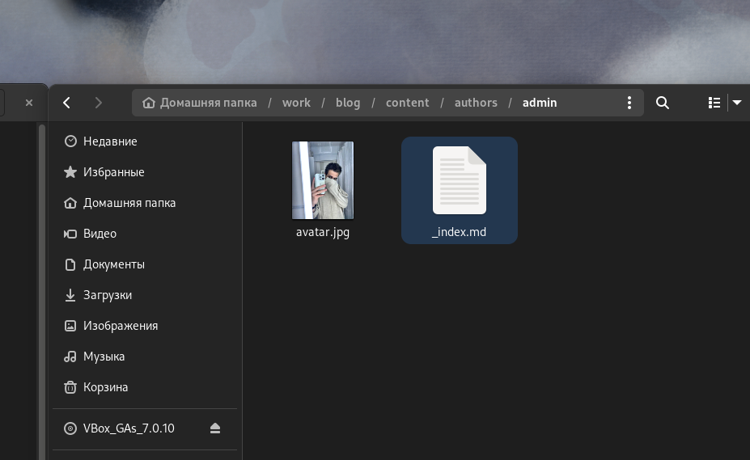

Добавление фотографии

## Выполнение лабораторной работы

В файле index.md в той же папке изменяю поля. Редактирую интересы, навыки, образования, достижения и пр.

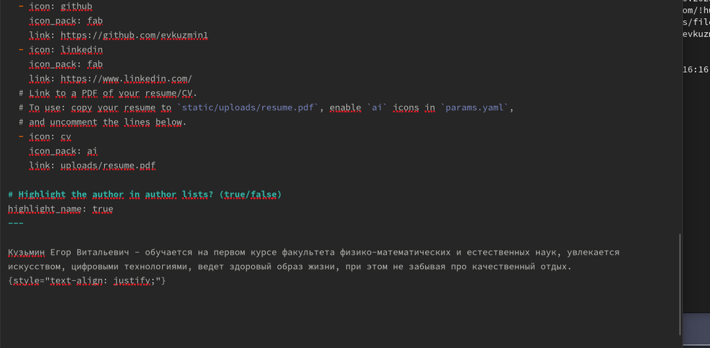

Обновление личных данных

## Выполнение лабораторной работы

Проверяю, что на локальном сайте все есть. Локальный сайт запускается с помощью hugo server

[figure not shown]

Локальный сайт

## Выполнение лабораторной работы

Создаю папки в директории post, которые обозначают посты и в которых будут тексты постов, картинки и доп. файлы. Заполняю файл index.md в post1 - про прошедшую неделю

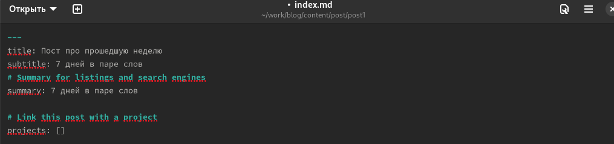

Пост про прошедшую неделю

## Выполнение лабораторной работы

Заполняю файл index.md в post2, это пост про управление версиями Git

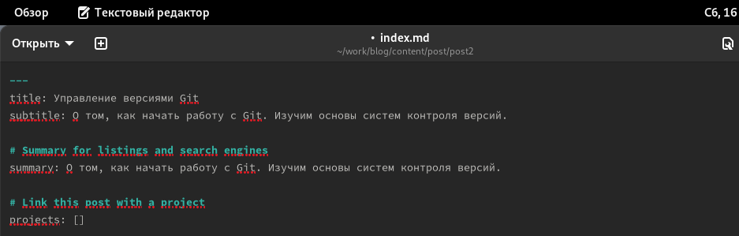

## Выполнение лабораторной работы

Закрываю локальный сервер. Генерирую сайт с изменениями

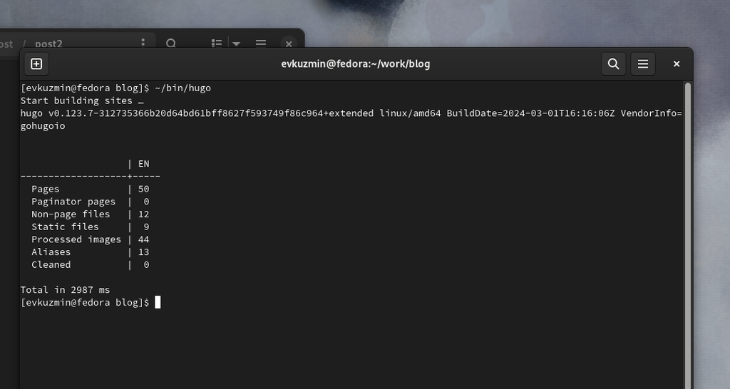

Генерация сайта

## Выполнение лабораторной работы

Отправляю данные в гитхаб.

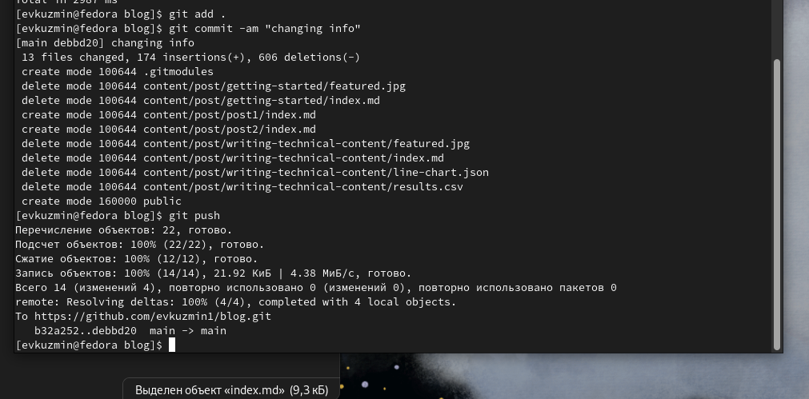

Сохранение в blog

## Выполнение лабораторной работы

Сохраняю изменения в папке, связанную с сайтом

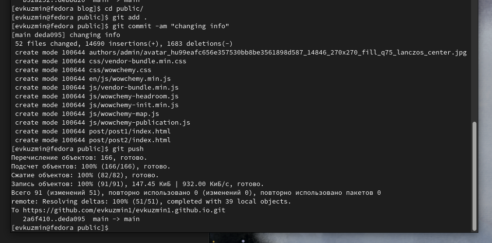

Сохранение в public

## Выполнение лабораторной работы

Проверяю, как выглядит сайт в браузере

[figure not shown]

Сайт в сети интернет

## Выводы

В процессе выполнения второго этапа индивидуального проекта я приобрел практические навыки изменения биографии, написания постов, редактирования сайта.